# An Introduction to PsychPower

# 1. Aim

This vignette outlines how `PsychPower` can be used to determine how many and which unique symptom phenotypes are present in a sample, and how the frequency distribution of all phenotypes in the same sample can be described mathematically. A detailed motivation for this analysis as well as the technicalities of the procedure are outlined in [Spiller et al. (2021)](https://psyarxiv.com/g4kf8/).

# 2. Installation

This package is currently only hosted on GitHub. Installation requires the `devtools` package to be installed and loaded.

```r
library("devtools")
devtools::install_github("orduek/PsychPower")
```

Once the `PsychPower` is installed it can be loaded the usual way.

```r
library("PsychPower")
```

# 3. Example

This example outlines the analysis performed in [Spiller et al. (2021)](https://psyarxiv.com/g4kf8/) using sample data also include in the same publication.

The sample data consist of 39,700 complete answers to the 13-item anxiety subscale of the Depression Anxiety Stress Scales (DASS; [Nieuwenhuijsen et al. (2003)](https://oem.bmj.com/content/60/suppl_1/i77.long)). All 13 items were rated on a 4-point Likert scale, ranging from 1 to 4. The raw data were collected and provided by the [Open-Source Psychometrics Project](https://openpsychometrics.org/about/).

## 3.1 Load Data

First, we load the sample data.

```r
data("data_test")
```

Next, we inspect the first 10 rows (participants) and 5 of the total 13 columns (questionnaire items) of the sample data.

```
#> # A tibble: 39,700 × 5
#>       Q2    Q7    Q9   Q15   Q19
#>    <dbl> <dbl> <dbl> <dbl> <dbl>
#>  1     4     4     2     4     3
#>  2     1     3     3     3     1
#>  3     1     1     2     4     2
#>  4     3     4     3     2     1
#>  5     2     4     4     4     4
#>  6     1     1     3     2     1
#>  7     1     3     3     3     1
#>  8     1     2     1     2     1
#>  9     4     4     4     4     4
#> 10     2     3     4     2     4
#> # … with 39,690 more rows
```

## 3.2 Define Phenotypes

As outlined in the publication, a phenotype is defined as a unique combination of a finite set of items (in this example symptoms) used to describe or define a psychological construct (in this example a mental disorder).

### 3.2.1 Binarize variables

Here, we are only interested in presence or absence of a symptom and not in their severity. Therefore, we need to dichotomize or `binarize` the participants answers. We have to choose a cut-off, defining which ratings should be indicative of symptom presence or absence.

In this example, a cut-off of 2 is chosen based on the literature.

```r
data_binarized <- binarize(data_test, cut_off = 2)
```

[output not shown]

```
#> # A tibble: 39,700 × 6
#>    v_bin1 v_bin2 v_bin3 v_bin4 v_bin5 v_bin6
#>     <dbl>  <dbl>  <dbl>  <dbl>  <dbl>  <dbl>
#>  1      1      1      0      1      1      1
#>  2      0      1      1      1      0      0
#>  3      0      0      0      1      0      0
#>  4      1      1      1      0      0      0
#>  5      0      1      1      1      1      1
#>  6      0      0      1      0      0      0
#>  7      0      1      1      1      0      1
#>  8      0      0      0      0      0      0
#>  9      1      1      1      1      1      1
#> 10      0      1      1      0      1      1
#> # … with 39,690 more rows
```

### 3.2.2 Determine Phenotye Frequency

Next, we determine the number of unique phenotypes in the sample and count how many times each unique phenotypes was reported.

```r
data_frequency <- pheno_frequency(data_binarized, target_columns = tidyselect::starts_with("v_bin"))
```

**NOTE**: The function `pheno_frequency()` uses `target_columns = tidyselect::starts_with("v_bin")` as default, expecting that the variables were dichotomized with `binarize()`. However, the columns used to define the phenotype of interest can also be selected manually using `target_columns = [j:k]` (e.g., if the ratings were already collected as a binary response).

The output of `pheno_frequency()` is a dataframe in which every row represents one unique phenotype. The frequency of each phenotype is indicated in the column “freq”. Hence, whenever there is at least one phenotype that is reported more than once, the dataframe has *not* the same length as the initial data.

## 3.3 Describe Phenotypes

Next, we explore the characteristics of the different phenotypes present in the sample.

### 3.3.1 Most common phenotypes

First, we inspect the symptom combinations of the most common phenotypes (in this example, the one of the 5 most common).

```r
common_pheno(data_frequency, frequency = "freq", n_phenotypes = 5)
```

```
#>   v_bin1 v_bin2 v_bin3 v_bin4 v_bin5 v_bin6 v_bin7 v_bin8 v_bin9 v_bin10
#> 1      0      0      0      0      0      0      0      0      0       0
#>   v_bin11 v_bin12 v_bin13 freq total_bin
#> 1       0       0       0 6999         0
#>   v_bin1 v_bin2 v_bin3 v_bin4 v_bin5 v_bin6 v_bin7 v_bin8 v_bin9 v_bin10
#> 2      1      1      1      1      1      1      1      1      1       1
#>   v_bin11 v_bin12 v_bin13 freq total_bin
#> 2       1       1       1 1094        13
#>   v_bin1 v_bin2 v_bin3 v_bin4 v_bin5 v_bin6 v_bin7 v_bin8 v_bin9 v_bin10
#> 3      0      0      1      0      0      0      0      0      0       0
#>   v_bin11 v_bin12 v_bin13 freq total_bin
#> 3       0       0       0  774         1
#>   v_bin1 v_bin2 v_bin3 v_bin4 v_bin5 v_bin6 v_bin7 v_bin8 v_bin9 v_bin10
#> 4      0      0      0      0      0      0      0      0      0       0
#>   v_bin11 v_bin12 v_bin13 freq total_bin
#> 4       0       1       0  707         1
#>   v_bin1 v_bin2 v_bin3 v_bin4 v_bin5 v_bin6 v_bin7 v_bin8 v_bin9 v_bin10
#> 5      1      0      0      0      0      0      0      0      0       0
#>   v_bin11 v_bin12 v_bin13 freq total_bin
#> 5       0       0       0  705         1
```

[output not shown]

### 3.3.2 Characteristics

Second, the number of unique phenotypes, the frequency of the most common phenotype and the median frequency of all phenotypes is described.

```r
desc_pheno <- describe_pheno(data_frequency, frequency = "freq")
desc_pheno
```

```
#>                   Number
#> Unique Phenotypes   4528
#> N most frequent     6999
#> Median frequency       2
```

### 3.3.3 Plot

Third, we plot the frequency of the most common phenotypes. In this plot, each bar represents a unique phenotype with its height corresponding to the frequency indicted on the Y axis.

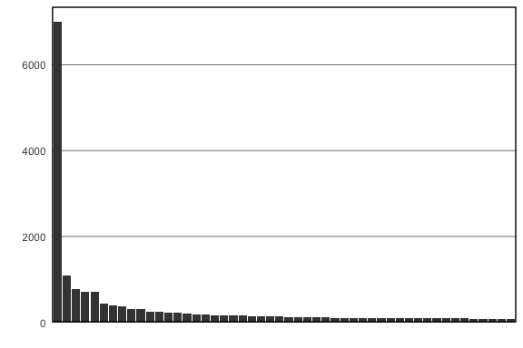

```r
fig1 <- plot_pheno(data_frequency, frequency = "freq", n_phenotypes = 50, color = "grey26")
fig1
```

## 3.4 Phenotype frequency distribution

The distribution shown in Figure 1 (see above) is starkly skewed. There are multiple skewed distributions and we would like to test which of these distributions best approximates the frequency distribution. We first determine the best fitting approximations relying on the methods developed by [Clauset et al, 2009](https://arxiv.org/abs/0706.1062) and implemented in the poweRlaw package. Subsequently the functions `describe_pheno_distr()`, `compare_pheno_distr()`, and `plot_pheno_distr()` are used to describe and plot the results as well as to test the comparative for of the three different distributions.

### 3.4.1 Estimate

The distributions can be approximated in the following way.

```r
freq_distribution <- pheno_distributions(data_frequency, frequency = "freq")
```

**NOTE**: The function `pheno_distributions()` outputs a list of three `poweRlaw` objects. These objects have the following order: 1. a power-law model, 2. a log-normal model and 3. an exponential model. This exact order must be present for the functions `describe_pheno_distr()`, `compare_pheno_distr()`, and `plot_pheno_distr()` to work. Importantly, these objects can be handled (e.g., visualized) like any other `poweRlaw` objects using the methods reported in the vignettes of the `poweRlaw` package.

To allow for direct comparisons of the three models, the minimum (Xmin) must be the same in all three models. Xmin of all distributions is set to the Xmin of the best fitting power-law model (for more details see [Clauset et al, 2009](https://arxiv.org/abs/0706.1062)).

### 3.4.2 Describe

The parameters of the best fitting distributions are obtained next. nBoots determines the number of simulations used to bootstrap the parameters. It should be set to 1000 or more which will result in an extended running time (it is set to 5 for illustrative purpose here).

```r
desc_freq <- describe_pheno_distr(freq_distribution, bootStrap = T, nBoots = 5, nCores = 1)
```

```
#> Expected total run time for 5 sims, using 1 threads is 0.801 seconds.
#> Expected total run time for 5 sims, using 1 threads is 7.09 seconds.
#> Expected total run time for 5 sims, using 1 threads is 0.341 seconds.
```

```r
desc_freq
```

```
#>                    PowerLaw   LogNormal Exponential
#> Xmin             7.00000000   7.0000000 7.000000000
#> SDxmin           1.14017543   0.0000000 5.540758071
#> alpha/exponent   2.10390844          NA 0.033436504
#> SDalpha/exponent 0.02677278          NA 0.001498277
#> log(mu)                  NA -16.9810407          NA
#> SDlog(mu)                NA   0.4326329          NA
#> log(sigma)               NA   4.3231911          NA
#> SDlog(sigma)             NA   0.1102218          NA
#> Boot_P_Value     0.00000000   0.8000000 0.000000000
```

### 3.4.3 Compare

The fit of the three distributions are compared using *one-sided* tests with alpha set to 0.05. Of note, the output is a list of *P* values. Because the tests are one-sided the output is not symmetric. The *P* value shown is always the one for testing the null hypothesis (HO) that the distribution in the row has equal fit to the distribution in the column.

```r
comp_fit_freq <- compare_pheno_distr(freq_distribution)
```

```
#> CAUTION: P values of one-sided tests (testing the distribution in the row).
#>                     Values < 0.05 indicate *refusal* of HO (no difference in fit).
```

Results:

```r
comp_fit_freq
```

```
#>             PowerLaw LogNormal Exponential
#> PowerLaw          NA    0.2783      0.9973
#> LogNormal     0.7217        NA      0.9974
#> Exponential   0.0027    0.0026          NA
```

Hence, the exponential distribution has a significant inferior fit compared to the power-law and the log-normal distribution (*P* = .0027 and .0026).

### 3.4.4 Plot

Finally, the phenotype frequency distributions and the best fitting approximated distributions are plotted. In this plot, the x-axis denotes the number of times phenotypes were reported and the y-axis the complementary cumulative distribution function (CDF), indicating the probability of a given value X (the frequency of a given phenotype) to take a value above x (a frequency higher than the one of a given phenotype). The black circles represent all phenotypes with the same specific frequency. The red solid line represents the best fitting power-law model. The blue dashed line corresponds to the best fitting log-normal model and the double dashed yellow line to the exponential model.

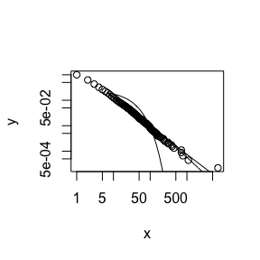

```r
fig2 <- plot_pheno_distr(freq_distribution, limity = 10^-4, limitx = 10^4)
```

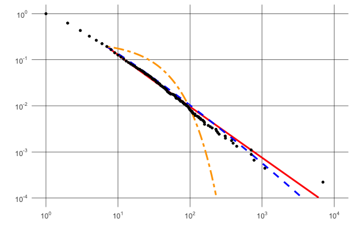

| **NOTE**: The limits of the x and y axis have to be chosen to depict the full distribution. `limity = 10^-j` and `limitx = 10^k` can be used to adjust the limits. |
| --- |

```r
fig2
```

# 4. Citation

To cite `PsychPower` in publications, please use:

Spiller, T. R., Duek, O., Helmer, M., Murray, J. D., von Känel, R., & Harpaz-Rotem, I. (2021, October 8). The uncommon is common: Structural similarities of symptom heterogeneity across mental disorders. DOI: 10.31234/osf.io/g4kf8